# Data Exploration

Felix Bigler

11/12/2021

# 1 Introduction

In this project work for machine learning 1, we would like to examine a dataset of bicycle rental numbers and build different models to predict the number of rentals at a given time.

Obviously, the number of rentals depends on the weather as well as on temporal or seasonal factors. These factors will be investigated.

The historical data is from the Capital BikeShare system for Washington D.C. USA.The data is available for the year 2011 to 2012.The dataset also contains weather data at the given time points.

# 2 Graphical Data Exploration

## 2.1 Influnece of Weather upon Bike Rentals

In this chapter we would like to explore how different weather conditions influence the bike rental numbers.

### 2.1.1 Exploration of Continuous Variables

We want to explore how different weather situation influences the number of bike rentals. For that we have following 4 continuous weather variables at hand which we are going to examine:

- temp: Normalized temperature in Celsius. t_min [-8], t_max [+39]
- atemp: Normalized feels like temperature in Celsius. t_min [-16], t_max [+50]
- hum: Normalized humidity. The values are divided with max. of 100
- windspeed: Normalized wind speed. The values are divided with min. of 67

The continuous weather variables are normalized as follows in the dataset:

```
## 'data.frame':    17379 obs. of  17 variables:
##  $ instant   : int  1 2 3 4 5 6 7 8 9 10 ...
##  $ dteday    : chr  "2011-01-01" "2011-01-01" "2011-01-01" "2011-01-01" ...
##  $ season    : int  1 1 1 1 1 1 1 1 1 1 ...
##  $ yr        : int  0 0 0 0 0 0 0 0 0 0 ...
##  $ mnth      : int  1 1 1 1 1 1 1 1 1 1 ...
##  $ hr        : int  0 1 2 3 4 5 6 7 8 9 ...
##  $ holiday   : int  0 0 0 0 0 0 0 0 0 0 ...
##  $ weekday   : int  6 6 6 6 6 6 6 6 6 6 ...
##  $ workingday: int  0 0 0 0 0 0 0 0 0 0 ...
##  $ weathersit: int  1 1 1 1 1 2 1 1 1 1 ...
##  $ temp      : num  0.24 0.22 0.22 0.24 0.24 0.24 0.22 0.2 0.24 0.32 ...
##  $ atemp     : num  0.288 0.273 0.273 0.288 0.288 ...
##  $ hum       : num  0.81 0.8 0.8 0.75 0.75 0.75 0.8 0.86 0.75 0.76 ...
##  $ windspeed : num  0 0 0 0 0 0.0896 0 0 0 0 ...
##  $ casual    : int  3 8 5 3 0 0 2 1 1 8 ...
##  $ registered: int  13 32 27 10 1 1 0 2 7 6 ...
##  $ cnt       : int  16 40 32 13 1 1 2 3 8 14 ...
```

```
##     instant         dteday              season            yr
##  Min.   :    1   Length:17379       Min.   :1.000   Min.   :0.0000
##  1st Qu.: 4346   Class :character   1st Qu.:2.000   1st Qu.:0.0000
##  Median : 8690   Mode  :character   Median :3.000   Median :1.0000
##  Mean   : 8690                      Mean   :2.502   Mean   :0.5026
##  3rd Qu.:13034                      3rd Qu.:3.000   3rd Qu.:1.0000
##  Max.   :17379                      Max.   :4.000   Max.   :1.0000
##       mnth              hr           holiday           weekday
##  Min.   : 1.000   Min.   : 0.00   Min.   :0.00000   Min.   :0.000
##  1st Qu.: 4.000   1st Qu.: 6.00   1st Qu.:0.00000   1st Qu.:1.000
##  Median : 7.000   Median :12.00   Median :0.00000   Median :3.000
##  Mean   : 6.538   Mean   :11.55   Mean   :0.02877   Mean   :3.004
##  3rd Qu.:10.000   3rd Qu.:18.00   3rd Qu.:0.00000   3rd Qu.:5.000
##  Max.   :12.000   Max.   :23.00   Max.   :1.00000   Max.   :6.000
##    workingday       weathersit         temp           atemp
##  Min.   :0.0000   Min.   :1.000   Min.   :0.020   Min.   :0.0000
##  1st Qu.:0.0000   1st Qu.:1.000   1st Qu.:0.340   1st Qu.:0.3333
##  Median :1.0000   Median :1.000   Median :0.500   Median :0.4848
##  Mean   :0.6827   Mean   :1.425   Mean   :0.497   Mean   :0.4758
##  3rd Qu.:1.0000   3rd Qu.:2.000   3rd Qu.:0.660   3rd Qu.:0.6212
##  Max.   :1.0000   Max.   :4.000   Max.   :1.000   Max.   :1.0000
##       hum           windspeed          casual         registered
##  Min.   :0.0000   Min.   :0.0000   Min.   :  0.00   Min.   :  0.0
##  1st Qu.:0.4800   1st Qu.:0.1045   1st Qu.:  4.00   1st Qu.: 34.0
##  Median :0.6300   Median :0.1940   Median : 17.00   Median :115.0
##  Mean   :0.6272   Mean   :0.1901   Mean   : 35.68   Mean   :153.8
##  3rd Qu.:0.7800   3rd Qu.:0.2537   3rd Qu.: 48.00   3rd Qu.:220.0
##  Max.   :1.0000   Max.   :0.8507   Max.   :367.00   Max.   :886.0
##       cnt
##  Min.   :  1.0
##  1st Qu.: 40.0
##  Median :142.0
##  Mean   :189.5
##  3rd Qu.:281.0
##  Max.   :977.0
```

$$x_{normalized} = \frac{x-x_{min}}{x_{max}-x_{min}}$$
For some models it may be useful to use the normalized variables and for other we may re-transform the variables. If so, we will state that in the coressponding chapter.

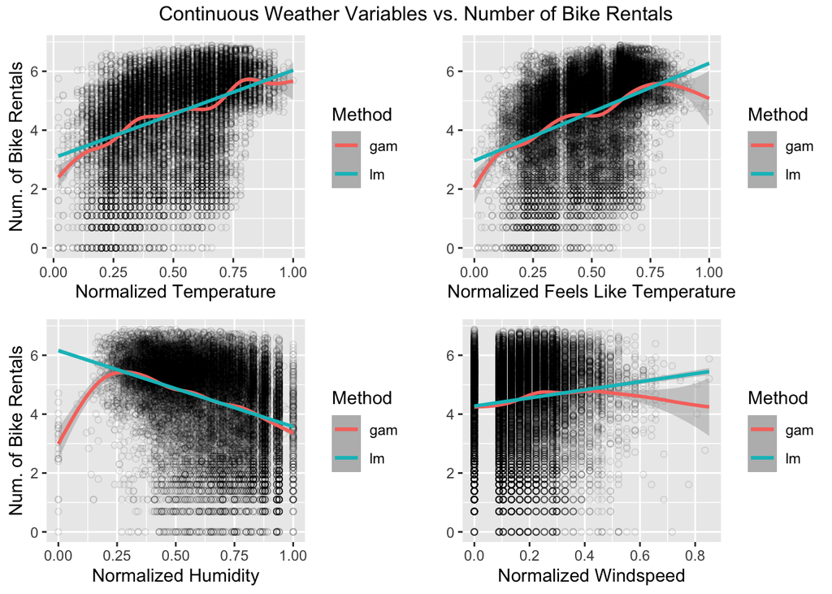

In all 4 scatter plots the linear model lines (green) as well as the gam model lines (red) are plotted. For both temperatur variables the rentals seems to increase until the temperature reaches a certain value.At the beginning of the obseravtions (low temp.) ans well as the end (high temp.) the linear model seems to overestimate the number of rentals. For the normalized humidity there is a decrease in rentals with increasing humidity. The is not the case between 0 and 25 % humidity where the linear model overestimates the number of rentals. We assume that in very cold and very hot weather the humidity is rather low and so the number of bike rentals because of the influence of temperature. In conclusion of the above exploration, it can be stated that the behavior cannot be completely represented with a linear model. There are nonlinear aspects which should be considered in the prediction models.

In the next chapter we would like to examine the categorical variables which are available in the dataset.

### 2.1.2 Exploration of Categorical Variables

The data set contains 4 different weather categories which are described as follows:

- Category 1: Clear, Few clouds, Partly cloudy, Partly cloudy
- Category 2: Mist + Cloudy, Mist + Broken clouds, Mist + Few clouds, Mist
- Category 3: Light Snow, Light Rain + Thunderstorm + Scattered clouds, Light Rain + Scattered clouds
- Category 4: Heavy Rain + Ice Pallets + Thunderstorm + Mist, Snow + Fog

Since we are considering the response variables count data we log transform the variable with the natural logarithm in all of the following plots.

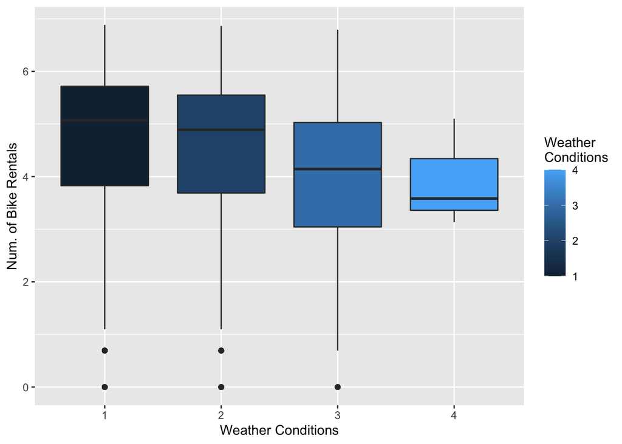

The boxplot above indicates, that in situation 1 and 2 the most bikes are rented whereas there is seems to be a drop visible for condition 3 and the drop is even more significant for situation 4 where severe weather conditions are present.This rental behavior is as we have expected since few people ride bicycles in bad weather situations.

In the next chapter we are inspecting the seasonal and timly influence upon the rental situation.

## 2.2 Influnece of Timely and Seasonal aspects upon Bike Rentals

### 2.2.1 Exploration of Categorical Variables

#### 2.2.1.1 Seasonal Influence

In order to investigate the seasonal influences, the monthly (1 to 12) and seasonal data are included in the dataset as shown below::

- Category 1: Spring
- Category 2: Summer
- Category 3: Fall
- Category 4: Winter

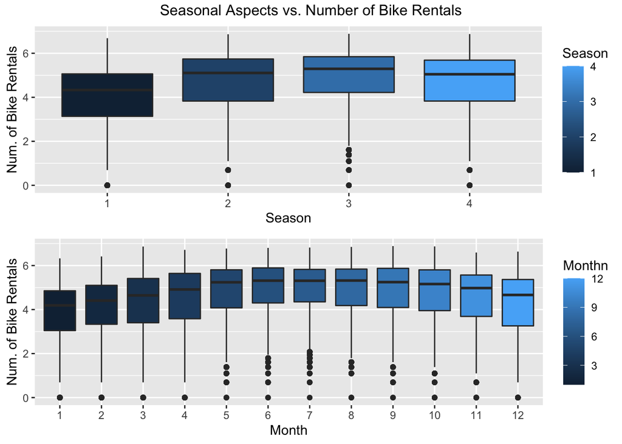

The two boxplot above indicate, that the mos bike rentals take place in summer and fall which we have expected.

#### 2.2.1.2 Timely Influence

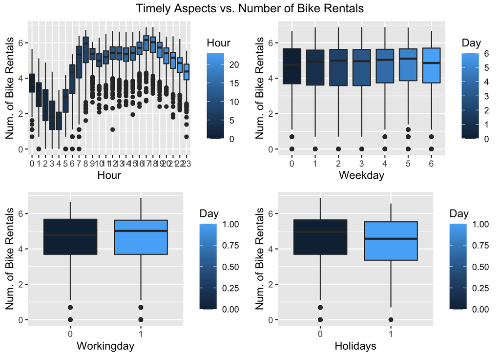

The above plots indicate, that the hour in which the bike is rented has the most influence of total rentals which seems obvious. On the other hand, whether there is a working day or not, seems not to have a significant influence.

In the next chapter we try to find a linear model which suits best the dateset. ```